# Draft Model to Project a College Player’s Highest WAR Season

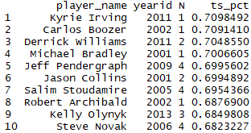

**Figure 16: Bottom 10 TS%**

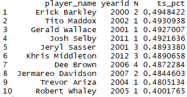

**Figure 17: Top 10 FG3a Per FGA**

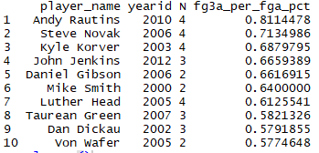

**Figure 18: Bottom 10 FG3a Per FGA**

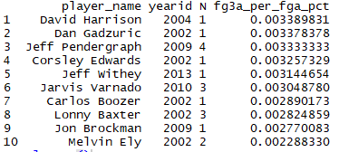

**Figure 19: Top 10 FTA Per FGA**

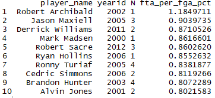

**Figure 20: Bottom 10 FTA Per FGA**

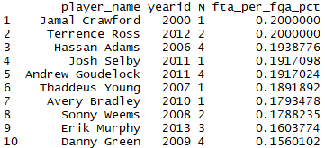

**Figure 21: Top 10 Usage%**

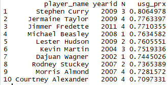

**Figure 22: Bottom 10 Usage%**

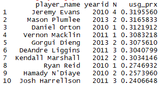

**Figure 23: Top 10 TS%/FG3a Per FGA**

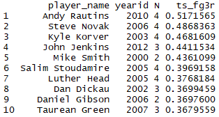

**Figure 24: Bottom 10 TS%/FG3a Per FGA**

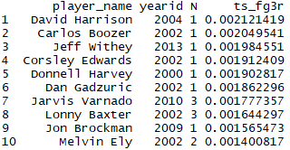

**Figure 25: Top 10 AST/TRB**

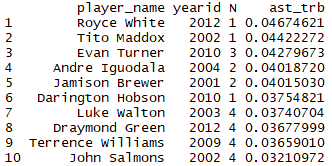

**Figure 26: Bottom 10 AST/TRB**

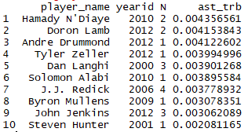